# Ensemble Techniques - Project 3

```python
import pandas as pd
import numpy as np
import matplotlib.pyplot as plt
from matplotlib.pyplot import figure
import seaborn as sns
import warnings

warnings.filterwarnings("ignore")
```

```python
data = pd.read_csv("Data_Parkinsons.csv")
```

```python
print('head of the data:')
data.head()
```

```
head of the data:
```

|  | name | MDVP:Fo(Hz) | MDVP:Fhi(Hz) | MDVP:Flo(Hz) | MDVP:Jitter(%) | MDVP:Jitter(Abs) | MDVP:RAP | MDVP:PPQ | Jitter:DDP | MDVP:Shimmer | ... | Shimmer:DDA | NHR | HNR | status | RPDE | DFA | spread1 | spread2 | D2 | PPE |
| --- | --- | --- | --- | --- | --- | --- | --- | --- | --- | --- | --- | --- | --- | --- | --- | --- | --- | --- | --- | --- | --- |
| 0 | phon_R01_S01_1 | 119.992 | 157.302 | 74.997 | 0.00784 | 0.00007 | 0.00370 | 0.00554 | 0.01109 | 0.04374 | ... | 0.06545 | 0.02211 | 21.033 | 1 | 0.414783 | 0.815285 | -4.813031 | 0.266482 | 2.301442 | 0.284654 |
| 1 | phon_R01_S01_2 | 122.400 | 148.650 | 113.819 | 0.00968 | 0.00008 | 0.00465 | 0.00696 | 0.01394 | 0.06134 | ... | 0.09403 | 0.01929 | 19.085 | 1 | 0.458359 | 0.819521 | -4.075192 | 0.335590 | 2.486855 | 0.368674 |
| 2 | phon_R01_S01_3 | 116.682 | 131.111 | 111.555 | 0.01050 | 0.00009 | 0.00544 | 0.00781 | 0.01633 | 0.05233 | ... | 0.08270 | 0.01309 | 20.651 | 1 | 0.429895 | 0.825288 | -4.443179 | 0.311173 | 2.342259 | 0.332634 |
| 3 | phon_R01_S01_4 | 116.676 | 137.871 | 111.366 | 0.00997 | 0.00009 | 0.00502 | 0.00698 | 0.01505 | 0.05492 | ... | 0.08771 | 0.01353 | 20.644 | 1 | 0.434969 | 0.819235 | -4.117501 | 0.334147 | 2.405554 | 0.368975 |
| 4 | phon_R01_S01_5 | 116.014 | 141.781 | 110.655 | 0.01284 | 0.00011 | 0.00655 | 0.00908 | 0.01966 | 0.06425 | ... | 0.10470 | 0.01767 | 19.649 | 1 | 0.417356 | 0.823484 | -3.747787 | 0.234513 | 2.332180 | 0.410335 |

5 rows × 24 columns

```python
print('shape of the data:')
data.shape
```

```
shape of the data:
```

```
(195, 24)
```

```python
print('data types')
data.dtypes
```

```
data types
```

```
name                 object
MDVP:Fo(Hz)         float64
MDVP:Fhi(Hz)        float64
MDVP:Flo(Hz)        float64
MDVP:Jitter(%)      float64
MDVP:Jitter(Abs)    float64
MDVP:RAP            float64
MDVP:PPQ            float64
Jitter:DDP          float64
MDVP:Shimmer        float64
MDVP:Shimmer(dB)    float64
Shimmer:APQ3        float64
Shimmer:APQ5        float64
MDVP:APQ            float64
Shimmer:DDA         float64
NHR                 float64
HNR                 float64
status                int64
RPDE                float64
DFA                 float64
spread1             float64
spread2             float64
D2                  float64
PPE                 float64
dtype: object
```

#### Observations

```python
print('checking for null values in the data:')
data.isnull().any()
```

```
checking for null values in the data:
```

```
name                False
MDVP:Fo(Hz)         False
MDVP:Fhi(Hz)        False
MDVP:Flo(Hz)        False
MDVP:Jitter(%)      False
MDVP:Jitter(Abs)    False
MDVP:RAP            False
MDVP:PPQ            False
Jitter:DDP          False
MDVP:Shimmer        False
MDVP:Shimmer(dB)    False
Shimmer:APQ3        False
Shimmer:APQ5        False
MDVP:APQ            False
Shimmer:DDA         False
NHR                 False
HNR                 False
status              False
RPDE                False
DFA                 False
spread1             False
spread2             False
D2                  False
PPE                 False
dtype: bool
```

```python
data.notnull().any()
```

```
name                True
MDVP:Fo(Hz)         True
MDVP:Fhi(Hz)        True
MDVP:Flo(Hz)        True
MDVP:Jitter(%)      True
MDVP:Jitter(Abs)    True
MDVP:RAP            True
MDVP:PPQ            True
Jitter:DDP          True
MDVP:Shimmer        True
MDVP:Shimmer(dB)    True
Shimmer:APQ3        True
Shimmer:APQ5        True
MDVP:APQ            True
Shimmer:DDA         True
NHR                 True
HNR                 True
status              True
RPDE                True
DFA                 True
spread1             True
spread2             True
D2                  True
PPE                 True
dtype: bool
```

#### Observations

There are no missing values

```python
print('five point summary of the data:')
data.describe().T
```

```
five point summary of the data:
```

|  | count | mean | std | min | 25% | 50% | 75% | max |
| --- | --- | --- | --- | --- | --- | --- | --- | --- |
| MDVP:Fo(Hz) | 195.0 | 154.228641 | 41.390065 | 88.333000 | 117.572000 | 148.790000 | 182.769000 | 260.105000 |
| MDVP:Fhi(Hz) | 195.0 | 197.104918 | 91.491548 | 102.145000 | 134.862500 | 175.829000 | 224.205500 | 592.030000 |
| MDVP:Flo(Hz) | 195.0 | 116.324631 | 43.521413 | 65.476000 | 84.291000 | 104.315000 | 140.018500 | 239.170000 |
| MDVP:Jitter(%) | 195.0 | 0.006220 | 0.004848 | 0.001680 | 0.003460 | 0.004940 | 0.007365 | 0.033160 |
| MDVP:Jitter(Abs) | 195.0 | 0.000044 | 0.000035 | 0.000007 | 0.000020 | 0.000030 | 0.000060 | 0.000260 |
| MDVP:RAP | 195.0 | 0.003306 | 0.002968 | 0.000680 | 0.001660 | 0.002500 | 0.003835 | 0.021440 |
| MDVP:PPQ | 195.0 | 0.003446 | 0.002759 | 0.000920 | 0.001860 | 0.002690 | 0.003955 | 0.019580 |
| Jitter:DDP | 195.0 | 0.009920 | 0.008903 | 0.002040 | 0.004985 | 0.007490 | 0.011505 | 0.064330 |
| MDVP:Shimmer | 195.0 | 0.029709 | 0.018857 | 0.009540 | 0.016505 | 0.022970 | 0.037885 | 0.119080 |
| MDVP:Shimmer(dB) | 195.0 | 0.282251 | 0.194877 | 0.085000 | 0.148500 | 0.221000 | 0.350000 | 1.302000 |
| Shimmer:APQ3 | 195.0 | 0.015664 | 0.010153 | 0.004550 | 0.008245 | 0.012790 | 0.020265 | 0.056470 |
| Shimmer:APQ5 | 195.0 | 0.017878 | 0.012024 | 0.005700 | 0.009580 | 0.013470 | 0.022380 | 0.079400 |
| MDVP:APQ | 195.0 | 0.024081 | 0.016947 | 0.007190 | 0.013080 | 0.018260 | 0.029400 | 0.137780 |
| Shimmer:DDA | 195.0 | 0.046993 | 0.030459 | 0.013640 | 0.024735 | 0.038360 | 0.060795 | 0.169420 |
| NHR | 195.0 | 0.024847 | 0.040418 | 0.000650 | 0.005925 | 0.011660 | 0.025640 | 0.314820 |
| HNR | 195.0 | 21.885974 | 4.425764 | 8.441000 | 19.198000 | 22.085000 | 25.075500 | 33.047000 |
| status | 195.0 | 0.753846 | 0.431878 | 0.000000 | 1.000000 | 1.000000 | 1.000000 | 1.000000 |
| RPDE | 195.0 | 0.498536 | 0.103942 | 0.256570 | 0.421306 | 0.495954 | 0.587562 | 0.685151 |
| DFA | 195.0 | 0.718099 | 0.055336 | 0.574282 | 0.674758 | 0.722254 | 0.761881 | 0.825288 |
| spread1 | 195.0 | -5.684397 | 1.090208 | -7.964984 | -6.450096 | -5.720868 | -5.046192 | -2.434031 |
| spread2 | 195.0 | 0.226510 | 0.083406 | 0.006274 | 0.174351 | 0.218885 | 0.279234 | 0.450493 |
| D2 | 195.0 | 2.381826 | 0.382799 | 1.423287 | 2.099125 | 2.361532 | 2.636456 | 3.671155 |
| PPE | 195.0 | 0.206552 | 0.090119 | 0.044539 | 0.137451 | 0.194052 | 0.252980 | 0.527367 |

#### Observations

1. There are 195 observations of all the variables
2. MDVP:Fo(Hz), MDVP:Fhi(Hz), MDVP:Flo(Hz) all have higher values compared to the most of the variables where the maximum and minimum are less than one. This shows the need of scaling these variables later when fitting the models
3. Spread1 has a negative mean and other values of max, min etc.

```
					Vocal fundamental frequencies
```

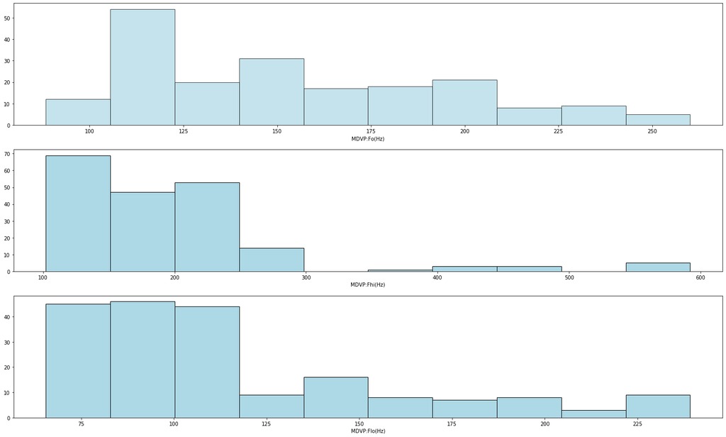

```python
#Plots to see the distribution of the vocal fundamental frequencies

print('\t\t\t\t\tVocal fundamental frequencies')
plt.figure(figsize= (25,15))

plt.subplot(3,1,1)
plt.hist(data['MDVP:Fo(Hz)'], color='lightblue', edgecolor = 'black', alpha = 0.7)
plt.xlabel('MDVP:Fo(Hz)')

plt.subplot(3,1,2)
plt.hist(data['MDVP:Fhi(Hz)'], color='lightblue', edgecolor = 'black')
plt.xlabel('MDVP:Fhi(Hz)')

plt.subplot(3,1,3)
plt.hist(data['MDVP:Flo(Hz)'], color='lightblue', edgecolor = 'black')
plt.xlabel('MDVP:Flo(Hz)')

plt.show()
```

#### Observations

##### Average vocal fundamental frequency has non uniform distribution.

1. There are more number of individuals with frequencies roughly between 110*Hz* and 120*Hz*.
2. There are less number of individuals greater than around 210*Hz*
3. The rest of the frequencies have individuals between 10 to 30 nos

##### Maximum vocal fundamental frequency has highly skewed distribution

1. Majority of the individuals are spread between 100*Hz* and 300*Hz*
2. The rest of them are spread between 350*Hz* to 580*Hz*
3. It is interesting to see approximately 300*Hz* to 350*Hz* and 480*Hz* to 550*Hz* there are no individuals

##### Minimum vocal fundamental frequecy has a skewed distribution

It has to be further examined to identify a pattern among these distributions.

```
					Several measures of variation in fundamental frequency
```

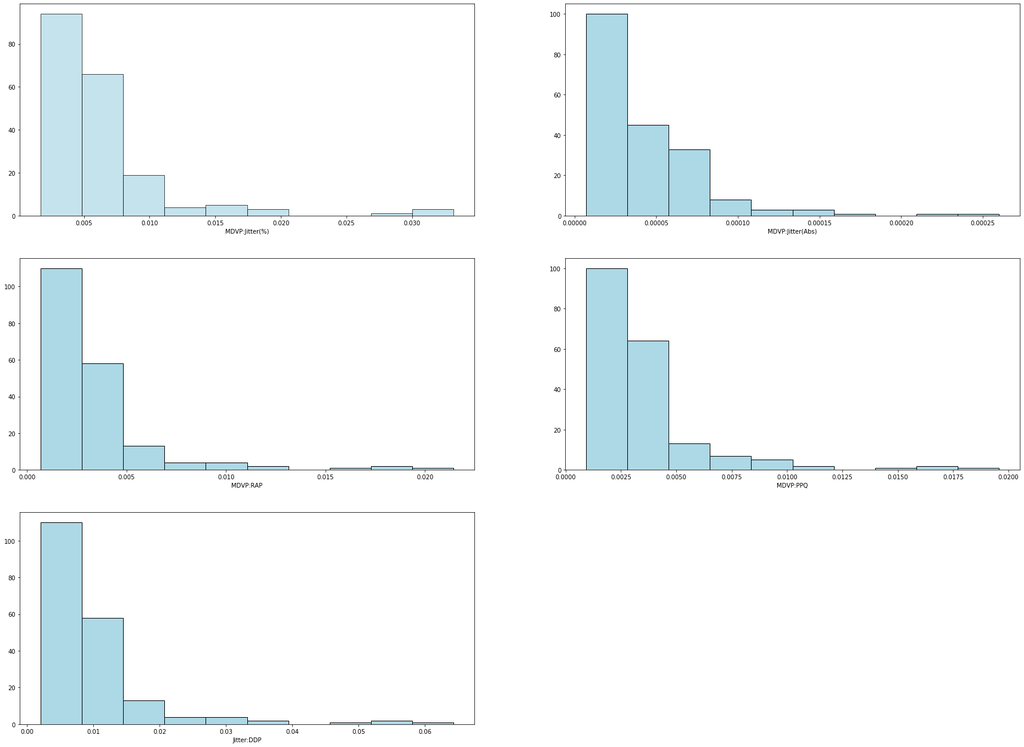

```python
plt.figure(figsize= (30,30))

print('\t\t\t\t\tSeveral measures of variation in fundamental frequency')

plt.subplot(4,2,1)
plt.hist(data['MDVP:Jitter(%)'], color='lightblue', edgecolor = 'black', alpha = 0.7)
plt.xlabel('MDVP:Jitter(%)')

plt.subplot(4,2,2)
plt.hist(data['MDVP:Jitter(Abs)'], color='lightblue', edgecolor = 'black')
plt.xlabel('MDVP:Jitter(Abs)')

plt.subplot(4,2,3)
plt.hist(data['MDVP:RAP'], color='lightblue', edgecolor = 'black')
plt.xlabel('MDVP:RAP')

plt.subplot(4,2,4)
plt.hist(data['MDVP:PPQ'], color='lightblue', edgecolor = 'black')
plt.xlabel('MDVP:PPQ')

plt.subplot(4,2,5)
plt.hist(data['Jitter:DDP'], color='lightblue', edgecolor = 'black')
plt.xlabel('Jitter:DDP')


plt.show()
```

#### Observations

A general trend across all the distributions of variations in fundamental freqency is all of them are highly skewed. There could be a likely influence of measure of variation on the other and hence the visible trend.

```
					Several measures of variation in amplitude
```

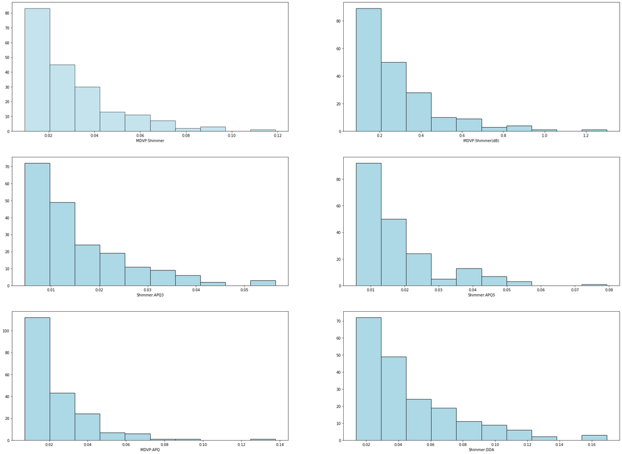

```python
plt.figure(figsize= (30,30))

print('\t\t\t\t\tSeveral measures of variation in amplitude')

plt.subplot(4,2,1)
plt.hist(data['MDVP:Shimmer'], color='lightblue', edgecolor = 'black', alpha = 0.7)
plt.xlabel('MDVP:Shimmer')

plt.subplot(4,2,2)
plt.hist(data['MDVP:Shimmer(dB)'], color='lightblue', edgecolor = 'black')
plt.xlabel('MDVP:Shimmer(dB)')

plt.subplot(4,2,3)
plt.hist(data['Shimmer:APQ3'], color='lightblue', edgecolor = 'black')
plt.xlabel('Shimmer:APQ3')

plt.subplot(4,2,4)
plt.hist(data['Shimmer:APQ5'], color='lightblue', edgecolor = 'black')
plt.xlabel('Shimmer:APQ5')

plt.subplot(4,2,5)
plt.hist(data['MDVP:APQ'], color='lightblue', edgecolor = 'black')
plt.xlabel('MDVP:APQ')

plt.subplot(4,2,6)
plt.hist(data['Shimmer:DDA'], color='lightblue', edgecolor = 'black')
plt.xlabel('Shimmer:DDA')

plt.show()
```

#### Observations

Just like the distributions of variations in fundamental frequency, there is a visible trend of high skewness and a similar distribution pattern across the various measures of variation in amplitude.

```
				Measures of ratio of noise to tonal components in the voice
```

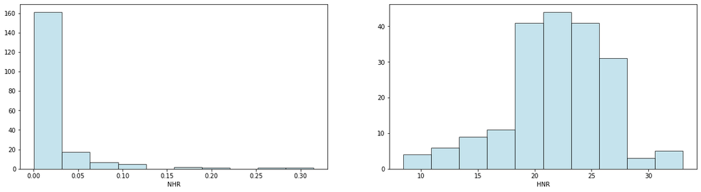

```python
plt.figure(figsize= (20,5))

print('\t\t\t\tMeasures of ratio of noise to tonal components in the voice')

plt.subplot(1,2,1)
plt.hist(data['NHR'], color='lightblue', edgecolor = 'black', alpha = 0.7)
plt.xlabel('NHR')

plt.subplot(1,2,2)
plt.hist(data['HNR'], color='lightblue', edgecolor = 'black', alpha = 0.7)
plt.xlabel('HNR')

plt.show()
```

#### Observations

1. NHR seems to have a highly skewed distribution, with most of the individuals in between 0.00 and around 0.03.
2. On the other hand HNR has majority of the individuals concentrated between 18 to 29.

```
				Three nonlinear measures of fundamental frequency variation
```

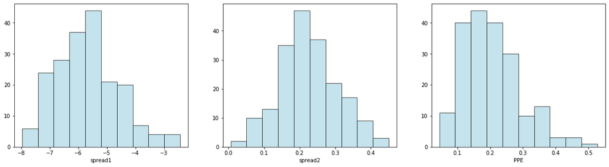

```python
plt.figure(figsize= (20,5))

print('\t\t\t\tThree nonlinear measures of fundamental frequency variation')

plt.subplot(1,3,1)
plt.hist(data['spread1'], color='lightblue', edgecolor = 'black', alpha = 0.7)
plt.xlabel('spread1')

plt.subplot(1,3,2)
plt.hist(data['spread2'], color='lightblue', edgecolor = 'black', alpha = 0.7)
plt.xlabel('spread2')

plt.subplot(1,3,3)
plt.hist(data['PPE'], color='lightblue', edgecolor = 'black', alpha = 0.7)
plt.xlabel('PPE')

plt.show()
```

#### Observations

The three distributions of the nonlinear measures of fundamental frequency have a lightly skewed normal distribution.

```
		Two nonlinear dynamical complexity measures and DFA - Signal fractal scaling exponent
```

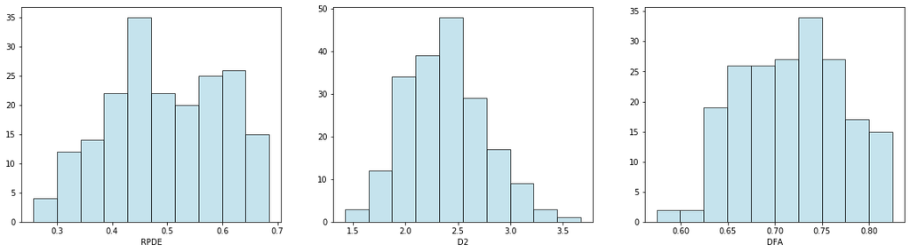

```python
plt.figure(figsize= (20,5))

print('\t\tTwo nonlinear dynamical complexity measures and DFA - Signal fractal scaling exponent')

plt.subplot(1,3,1)
plt.hist(data['RPDE'], color='lightblue', edgecolor = 'black', alpha = 0.7)
plt.xlabel('RPDE')

plt.subplot(1,3,2)
plt.hist(data['D2'], color='lightblue', edgecolor = 'black', alpha = 0.7)
plt.xlabel('D2')

plt.subplot(1,3,3)
plt.hist(data['DFA'], color='lightblue', edgecolor = 'black', alpha = 0.7)
plt.xlabel('DFA')

plt.show()
```

#### Observations

Honestly, I am unable to guess the impact of the complexity parameters which follows a certain skewed form of normal distribution and also the signal fractal scaling exponent which follows a non uniform distribution.

```python
print(data.status.value_counts())
```

```
1    147
0     48
Name: status, dtype: int64
```

#### Observations

In the given data set, there are 147 individuals with PD and 48 healthy. Majority being PD, the challenge will be to identify the healthy ones correctly.

```python
data.columns
```

```
Index(['name', 'MDVP:Fo(Hz)', 'MDVP:Fhi(Hz)', 'MDVP:Flo(Hz)', 'MDVP:Jitter(%)',
       'MDVP:Jitter(Abs)', 'MDVP:RAP', 'MDVP:PPQ', 'Jitter:DDP',
       'MDVP:Shimmer', 'MDVP:Shimmer(dB)', 'Shimmer:APQ3', 'Shimmer:APQ5',
       'MDVP:APQ', 'Shimmer:DDA', 'NHR', 'HNR', 'status', 'RPDE', 'DFA',
       'spread1', 'spread2', 'D2', 'PPE'],
      dtype='object')
```

```python
# Measure the skeweness of the required columns
data.skew()
```

```
MDVP:Fo(Hz)         0.591737
MDVP:Fhi(Hz)        2.542146
MDVP:Flo(Hz)        1.217350
MDVP:Jitter(%)      3.084946
MDVP:Jitter(Abs)    2.649071
MDVP:RAP            3.360708
MDVP:PPQ            3.073892
Jitter:DDP          3.362058
MDVP:Shimmer        1.666480
MDVP:Shimmer(dB)    1.999389
Shimmer:APQ3        1.580576
Shimmer:APQ5        1.798697
MDVP:APQ            2.618047
Shimmer:DDA         1.580618
NHR                 4.220709
HNR                -0.514317
status             -1.187727
RPDE               -0.143402
DFA                -0.033214
spread1             0.432139
spread2             0.144430
D2                  0.430384
PPE                 0.797491
dtype: float64
```

#### Observations

MDVP:Fhi(Hz),MDVP:Flo(Hz), MDVP:Jitter(%), MDVP:Jitter(Abs), MDVP:RAP, MDVP:PPQ, Jitter:DDP, MDVP:APQ, NHR all exhibit Skewness as observed earlier from the distributions.

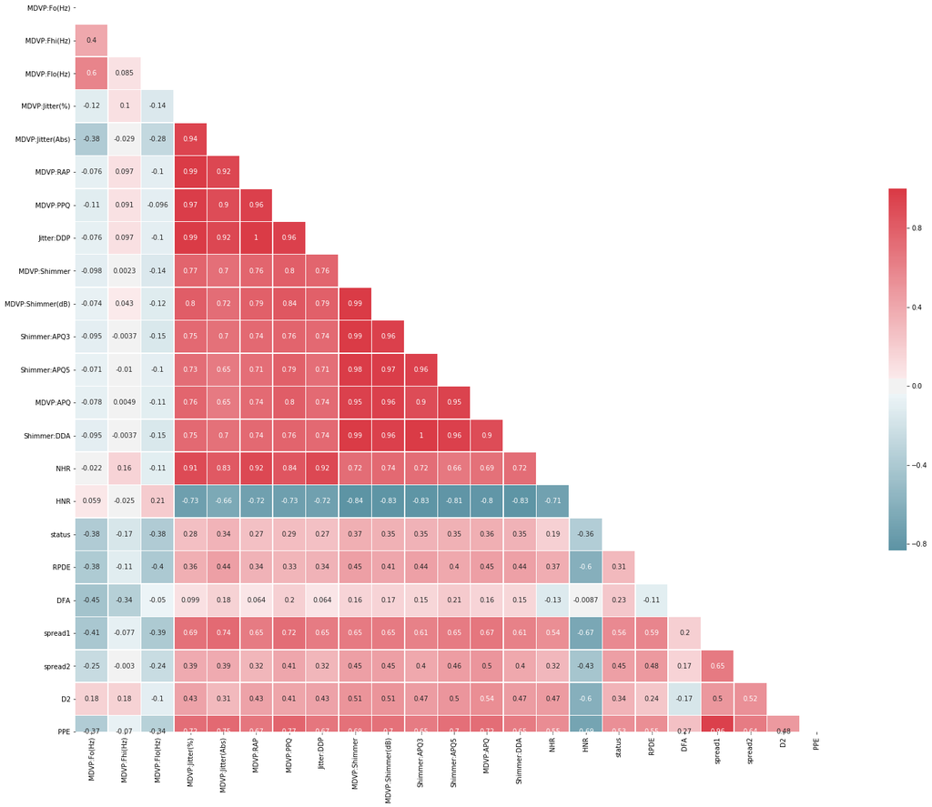

```python
# Correlation matrix for all variables
corr = data.corr()

mask = np.zeros_like(corr, dtype = np.bool)
mask[np.triu_indices_from(mask)] = True

f, ax = plt.subplots(figsize = (30, 20))

cmap = sns.diverging_palette(220, 10, as_cmap = True)

sns.heatmap(corr, mask = mask, cmap = cmap, vmax = 1, center = 0, square = True,
            linewidths = .5, cbar_kws = {"shrink": .5}, annot = True)
```

#### Observations

```python
# preparing data
# eliminating columns of 'name', 'MDVP:Fo(Hz)', 'MDVP:Fhi(Hz)', 'MDVP:Flo(Hz)', 'HNR' and Experience
# as they dont influence the predictor variable, observed from the Correlation matrix

from sklearn.model_selection import train_test_split

X = data.drop(columns = ['name', 'MDVP:Fo(Hz)', 'MDVP:Fhi(Hz)', 'MDVP:Flo(Hz)', 'HNR', 'status'], axis='columns')
Y = data['status']
```

```python
x_train, x_test, y_train, y_test = train_test_split(X, Y, test_size=0.3, random_state=22)

#check the data split

print("{0:0.2f}% data is in training set".format((len(x_train)/len(data.index)) * 100))
print("{0:0.2f}% data is in test set".format((len(x_test)/len(data.index)) * 100))
```

```
69.74% data is in training set
30.26% data is in test set
```

```python
#checking the distribution of predictor class in the parent, train and test dataset in percentages

print((Y.value_counts()/len(Y))*100)
print((y_train.value_counts()/len(y_train))*100)
print((y_test.value_counts()/len(y_test))*100)
```

```
1    75.384615
0    24.615385
Name: status, dtype: float64
1    77.205882
0    22.794118
Name: status, dtype: float64
1    71.186441
0    28.813559
Name: status, dtype: float64
```

#### Observation

The Status variable is following a similar distribution in the parent, test and train splits.

#### Fitting standard classification algorithms

1. Logistic Regression
2. Naive Bayes
3. SVM
4. KNN

```python
# Logistic Regression - non scaled version

from sklearn import metrics
from sklearn.metrics import classification_report, confusion_matrix, roc_auc_score, roc_curve, accuracy_score

from sklearn.linear_model import LogisticRegression

# Fit the model on train
lr = LogisticRegression(C=1e5, random_state=22)
lr.fit(x_train, y_train)

from sklearn import metrics

lr_train_predict = lr.predict(x_train)
lr_test_predict = lr.predict(x_test)


print("Model Accuracy for Training Data: {0:.4f}".format(metrics.accuracy_score(y_train, lr_train_predict)))
print("Model Accuracy for Testing Data: {0:.4f}".format(metrics.accuracy_score(y_test, lr_test_predict)))

cm=metrics.confusion_matrix(y_test, lr_test_predict, labels=[1, 0])
print('\nConfusion Matrix:\n', cm)

# Classification Report
print('\n{}'.format(classification_report(y_test, lr_test_predict)))

# Accuracy Score
auc = accuracy_score(y_test, lr_test_predict)
print('\nAccuracy Score:\n', auc.round(3))
```

```
Model Accuracy for Training Data: 0.8824
Model Accuracy for Testing Data: 0.7966

Confusion Matrix:
 [[39  3]
 [ 9  8]]

              precision    recall  f1-score   support

           0       0.73      0.47      0.57        17
           1       0.81      0.93      0.87        42

    accuracy                           0.80        59
   macro avg       0.77      0.70      0.72        59
weighted avg       0.79      0.80      0.78        59


Accuracy Score:
 0.797
```

```python
#Naive Bayes - non scaled version

from sklearn.naive_bayes import GaussianNB # using Gaussian algorithm from Naive Bayes

# create the model
nb = GaussianNB()

nb.fit(x_train, y_train)

from sklearn import metrics

nb_train_predict = nb.predict(x_train)
nb_test_predict = nb.predict(x_test)


print("Model Accuracy for Training Data: {0:.4f}".format(metrics.accuracy_score(y_train, nb_train_predict)))
print("Model Accuracy for Testing Data: {0:.4f}".format(metrics.accuracy_score(y_test, nb_test_predict)))

cm=metrics.confusion_matrix(y_test, nb_test_predict, labels=[1, 0])
print('\nConfusion Matrix:\n', cm)

# Classification Report
print('\n{}'.format(classification_report(y_test, nb_test_predict)))

# Accuracy Score
auc = accuracy_score(y_test, nb_test_predict)
print('\nAccuracy Score:\n', auc.round(3))
```

```
Model Accuracy for Training Data: 0.6985
Model Accuracy for Testing Data: 0.6441

Confusion Matrix:
 [[24 18]
 [ 3 14]]

              precision    recall  f1-score   support

           0       0.44      0.82      0.57        17
           1       0.89      0.57      0.70        42

    accuracy                           0.64        59
   macro avg       0.66      0.70      0.63        59
weighted avg       0.76      0.64      0.66        59


Accuracy Score:
 0.644
```

```python
#KNN - non scaled version

from sklearn.neighbors import KNeighborsClassifier

NNH = KNeighborsClassifier(n_neighbors= 5 , weights = 'distance' )
NNH.fit(x_train, y_train)

# For every test data point, predict it's label based on 5 nearest neighbours in this model.

NNH_train_predict = NNH.predict(x_train)
NNH_test_predict = NNH.predict(x_test)


print('k-NN accuracy for train set: {0:.3f}'.format(NNH.score(x_train, y_train)))
print('k-NN accuracy for test set: {0:.3f}'.format(NNH.score(x_test, y_test)))

# Classification Report
print('\n{}'.format(classification_report(y_test, NNH_test_predict)))

# Confusion Matrix
cm = confusion_matrix(y_test, NNH_test_predict)
print('\nConfusion Matrix:\n', cm)

# Accuracy Score
auc = accuracy_score(y_test, NNH_test_predict)
print('\nAccuracy Score:\n', auc.round(3))
```

```
k-NN accuracy for train set: 1.000
k-NN accuracy for test set: 0.847

              precision    recall  f1-score   support

           0       0.79      0.65      0.71        17
           1       0.87      0.93      0.90        42

    accuracy                           0.85        59
   macro avg       0.83      0.79      0.80        59
weighted avg       0.84      0.85      0.84        59


Confusion Matrix:
 [[11  6]
 [ 3 39]]

Accuracy Score:
 0.847
```

```python
#SVM - non scaled version

from sklearn import svm

SVM = svm.SVC(gamma=0.025, C=3)
SVM.fit(x_train, y_train)

# For every test data point, predict it's label based on 5 nearest neighbours in this model.

SVM_train_predict = SVM.predict(x_train)
SVM_test_predict = SVM.predict(x_test)

print('SVM accuracy for train set: {0:.3f}'.format(SVM.score(x_train, y_train)))
print('SVM accuracy for test set: {0:.3f}'.format(SVM.score(x_test, y_test)))

# Classification Report
print('\n{}'.format(classification_report(y_test, SVM_test_predict)))

# Confusion Matrix
cm = confusion_matrix(y_test, SVM_test_predict)
print('\nConfusion Matrix:\n', cm)

# Accuracy Score
auc = accuracy_score(y_test, SVM_test_predict)
print('\nAccuracy Score:\n', auc.round(3))
```

```
SVM accuracy for train set: 0.868
SVM accuracy for test set: 0.780

              precision    recall  f1-score   support

           0       0.75      0.35      0.48        17
           1       0.78      0.95      0.86        42

    accuracy                           0.78        59
   macro avg       0.77      0.65      0.67        59
weighted avg       0.77      0.78      0.75        59


Confusion Matrix:
 [[ 6 11]
 [ 2 40]]

Accuracy Score:
 0.78
```

#### Scaling the data as observed earlier

```python
from scipy.stats import zscore
XScaled  = X.apply(zscore)  # convert all attributes to Z scale
```

```python
# summary of the scaled variables
XScaled.describe().T
```

|  | count | mean | std | min | 25% | 50% | 75% | max |
| --- | --- | --- | --- | --- | --- | --- | --- | --- |
| MDVP:Jitter(%) | 195.0 | -2.127927e-17 | 1.002574 | -0.938949 | -0.570852 | -0.264794 | 0.236686 | 5.570985 |
| MDVP:Jitter(Abs) | 195.0 | 2.562053e-18 | 1.002574 | -1.064103 | -0.689814 | -0.401899 | 0.461845 | 6.220139 |
| MDVP:RAP | 195.0 | -1.380662e-16 | 1.002574 | -0.887254 | -0.556191 | -0.272422 | 0.178568 | 6.125892 |
| MDVP:PPQ | 195.0 | 9.351494e-17 | 1.002574 | -0.918044 | -0.576461 | -0.274850 | 0.184833 | 5.862742 |
| Jitter:DDP | 195.0 | 1.015569e-16 | 1.002574 | -0.887333 | -0.555707 | -0.273628 | 0.178487 | 6.126923 |
| MDVP:Shimmer | 195.0 | 2.818258e-16 | 1.002574 | -1.072340 | -0.702029 | -0.358302 | 0.434690 | 4.751617 |
| MDVP:Shimmer(dB) | 195.0 | -1.374969e-16 | 1.002574 | -1.014787 | -0.688103 | -0.315116 | 0.348543 | 5.246243 |
| Shimmer:APQ3 | 195.0 | 8.255505e-17 | 1.002574 | -1.097467 | -0.732604 | -0.283808 | 0.454311 | 4.029374 |
| Shimmer:APQ5 | 195.0 | 1.930080e-16 | 1.002574 | -1.015461 | -0.691934 | -0.367574 | 0.375369 | 5.129875 |
| MDVP:APQ | 195.0 | -8.824850e-17 | 1.002574 | -0.999305 | -0.650851 | -0.344401 | 0.314645 | 6.726438 |
| Shimmer:DDA | 195.0 | -1.577086e-16 | 1.002574 | -1.097815 | -0.732618 | -0.284146 | 0.454311 | 4.029746 |
| NHR | 195.0 | 5.152574e-17 | 1.002574 | -0.600205 | -0.469359 | -0.327104 | 0.019668 | 7.192738 |
| RPDE | 195.0 | -1.913000e-16 | 1.002574 | -2.333888 | -0.744921 | -0.024900 | 0.858713 | 1.800007 |
| DFA | 195.0 | 5.687758e-16 | 1.002574 | -2.605676 | -0.785262 | 0.075279 | 0.793250 | 1.942048 |
| spread1 | 195.0 | 1.184451e-15 | 1.002574 | -2.097268 | -0.704150 | -0.033540 | 0.586904 | 2.989093 |
| spread2 | 195.0 | -1.429056e-16 | 1.002574 | -2.647338 | -0.626984 | -0.091660 | 0.633762 | 2.692370 |
| D2 | 195.0 | -6.117614e-16 | 1.002574 | -2.510472 | -0.740410 | -0.053151 | 0.666891 | 3.376831 |
| PPE | 195.0 | -2.960595e-17 | 1.002574 | -1.802384 | -0.768742 | -0.139058 | 0.516514 | 3.569059 |

```python
#preparing the new training and testing data set
x_trainS, x_testS, y_trainS, y_testS = train_test_split(XScaled, Y, test_size=0.3, random_state=22)
```

```python
#check the data split

print("{0:0.2f}% data is in training set".format((len(x_trainS)/len(data.index)) * 100))
print("{0:0.2f}% data is in test set".format((len(x_testS)/len(data.index)) * 100))
```

```
69.74% data is in training set
30.26% data is in test set
```

```python
# Logistic Regression

# Fit the model on train
lr_scale = LogisticRegression(C=1e5, random_state=22)
lr_scale.fit(x_trainS, y_trainS)


lr_scale_train_predict = lr_scale.predict(x_trainS)
lr_scale_test_predict = lr_scale.predict(x_testS)

print("Model Accuracy for Training Data: {0:.4f}".format(metrics.accuracy_score(y_trainS, lr_scale_train_predict)))
print("Model Accuracy for Testing Data: {0:.4f}".format(metrics.accuracy_score(y_testS, lr_scale_test_predict)))

cm=metrics.confusion_matrix(y_testS, lr_scale_test_predict, labels=[1, 0])
print('\nConfusion Matrix:\n', cm)

# Classification Report
print('\n{}'.format(classification_report(y_testS, lr_scale_test_predict)))

# Accuracy Score
auc = accuracy_score(y_testS, lr_scale_test_predict)
print('\nAccuracy Score:\n', auc.round(3))
```

```
Model Accuracy for Training Data: 0.9338
Model Accuracy for Testing Data: 0.8136

Confusion Matrix:
 [[39  3]
 [ 8  9]]

              precision    recall  f1-score   support

           0       0.75      0.53      0.62        17
           1       0.83      0.93      0.88        42

    accuracy                           0.81        59
   macro avg       0.79      0.73      0.75        59
weighted avg       0.81      0.81      0.80        59


Accuracy Score:
 0.814
```

```python
#Naive Bayes

# create the model
nb_scale = GaussianNB()

nb_scale.fit(x_trainS, y_trainS)

nb_scale_train_predict = nb_scale.predict(x_trainS)
nb_scale_test_predict = nb_scale.predict(x_testS)


print("Model Accuracy for Training Data: {0:.4f}".format(metrics.accuracy_score(y_trainS, nb_scale_train_predict)))
print("Model Accuracy for Testing Data: {0:.4f}".format(metrics.accuracy_score(y_testS, nb_scale_test_predict)))

cm=metrics.confusion_matrix(y_testS, nb_scale_test_predict, labels=[1, 0])
print('\nConfusion Matrix:\n', cm)

# Classification Report
print('\n{}'.format(classification_report(y_testS, nb_scale_test_predict)))

# Accuracy Score
auc = accuracy_score(y_testS, nb_scale_test_predict)
print('\nAccuracy Score:\n', auc.round(3))
```

```
Model Accuracy for Training Data: 0.6985
Model Accuracy for Testing Data: 0.6610

Confusion Matrix:
 [[25 17]
 [ 3 14]]

              precision    recall  f1-score   support

           0       0.45      0.82      0.58        17
           1       0.89      0.60      0.71        42

    accuracy                           0.66        59
   macro avg       0.67      0.71      0.65        59
weighted avg       0.77      0.66      0.68        59


Accuracy Score:
 0.661
```

```python
# KNN Calssifier

NNH_scale = KNeighborsClassifier(n_neighbors= 5 , weights = 'distance' )
NNH_scale.fit(x_trainS, y_trainS)

# For every test data point, predict it's label based on 5 nearest neighbours in this model

NNH_scale_train_predict = NNH_scale.predict(x_trainS)
NNH_scale_test_predict = NNH_scale.predict(x_testS)

print('k-NN accuracy for train set: {0:.3f}'.format(NNH_scale.score(x_trainS, y_trainS)))
print('k-NN accuracy for test set: {0:.3f}'.format(NNH_scale.score(x_testS, y_testS)))

# Classification Report
print('\n{}'.format(classification_report(y_testS,NNH_scale_test_predict )))

# Confusion Matrix
cm = confusion_matrix(y_testS, NNH_scale_test_predict)
print('\nConfusion Matrix:\n', cm)

# Accuracy Score
auc = accuracy_score(y_testS, NNH_scale_test_predict)
print('\nAccuracy Score:\n', auc.round(3))
```

```
k-NN accuracy for train set: 1.000
k-NN accuracy for test set: 0.814

              precision    recall  f1-score   support

           0       0.69      0.65      0.67        17
           1       0.86      0.88      0.87        42

    accuracy                           0.81        59
   macro avg       0.77      0.76      0.77        59
weighted avg       0.81      0.81      0.81        59


Confusion Matrix:
 [[11  6]
 [ 5 37]]

Accuracy Score:
 0.814
```

```python
#SVM - scaled version

from sklearn import svm

SVM = svm.SVC(gamma=0.025, C=3, random_state=22)
SVM.fit(x_trainS, y_trainS)

# For every test data point, predict it's label based on 5 nearest neighbours in this model.

SVM_train_predict = SVM.predict(x_trainS)
SVM_test_predict = SVM.predict(x_testS)

print('SVM accuracy for train set: {0:.3f}'.format(SVM.score(x_trainS, y_trainS)))
print('SVM accuracy for test set: {0:.3f}'.format(SVM.score(x_testS, y_testS)))

# Classification Report
print('\n{}'.format(classification_report(y_testS, SVM_test_predict)))

# Confusion Matrix
cm = confusion_matrix(y_testS, SVM_test_predict)
print('\nConfusion Matrix:\n', cm)

# Accuracy Score
auc = accuracy_score(y_testS, SVM_test_predict)
print('\nAccuracy Score:\n', auc.round(3))
```

```
SVM accuracy for train set: 0.912
SVM accuracy for test set: 0.864

              precision    recall  f1-score   support

           0       0.91      0.59      0.71        17
           1       0.85      0.98      0.91        42

    accuracy                           0.86        59
   macro avg       0.88      0.78      0.81        59
weighted avg       0.87      0.86      0.85        59


Confusion Matrix:
 [[10  7]
 [ 1 41]]

Accuracy Score:
 0.864
```

### Using cross validation to check if the models improve further

#### Cross validation on the unscaled dataset using ten folds

Note: all the estimators are set to default and the results might vary if the parameters were tuned further

```python
from sklearn.model_selection import cross_val_score
```

```python
lr_cvs = cross_val_score(LogisticRegression(), X, Y,cv=10)
lr_cvs_mean = lr_cvs.mean()

nb_cvs = cross_val_score(GaussianNB(), X, Y,cv=10)
nb_cvs_mean = nb_cvs.mean()

nnh_cvs = cross_val_score(KNeighborsClassifier(), X, Y,cv=10)
nnh_cvs_mean = nnh_cvs.mean()

svm_cvs = cross_val_score(svm.SVC(), X, Y,cv=10)
svm_cvs_mean = svm_cvs.mean()

print(lr_cvs_mean)
print(nb_cvs_mean)
print(nnh_cvs_mean)
print(svm_cvs_mean)
```

```
0.8492105263157894
0.6799999999999999
0.8392105263157894
0.8039473684210525
```

#### Cross validation on the scaled dataset using ten folds

```python
lr_scaled_cvs = cross_val_score(LogisticRegression(), XScaled, Y,cv=10)
lr_scaled_cvs_mean = lr_scaled_cvs.mean()

nb_scaled_cvs = cross_val_score(GaussianNB(), XScaled, Y,cv=10)
nb_scaled_cvs_mean = nb_scaled_cvs.mean()

nnh_scaled_cvs = cross_val_score(KNeighborsClassifier(), XScaled, Y,cv=10)
nnh_scaled_cvs_mean = nnh_scaled_cvs.mean()

svm_scaled_cvs = cross_val_score(svm.SVC(), XScaled, Y,cv=10)
svm_scaled_cvs_mean = svm_scaled_cvs.mean()

print(lr_scaled_cvs_mean)
print(nb_scaled_cvs_mean)
print(nnh_scaled_cvs_mean)
print(svm_scaled_cvs_mean)
```

```
0.8289473684210525
0.6799999999999999
0.8155263157894737
0.8394736842105264
```

#### Output - Comparing Accuracies across models

1. Type 1 models - without scaling
   1. Logistic Regression: 0.797
   2. Naive Bayes: 0.644
   3. KNN: 0.847
   4. SVM: 0.780
2. Type 2 models - with scaling
   1. Logistic Regression: 0.814
   2. Naive Bayes: 0.661
   3. KNN: 0.814
   4. SVM: 0.864
3. Type 3 models - without scaling and Crossvalidation
   1. Logistic Regression: 0.849
   2. Naive Bayes: 0.679
   3. KNN: 0.839
   4. SVM: 0.803
4. Type 4 models - with scaling and Crossvalidation
   1. Logistic Regression: 0.828
   2. Naive Bayes: 0.679
   3. KNN: 0.815
   4. SVM: 0.839

### Decision Tree Classifier

##### before we proceed with Ensemble methods, checking if the Decision tree gives a good accuracy

```python
from sklearn.tree import DecisionTreeClassifier

#fitting a base model of Decision tree

clf_DT = DecisionTreeClassifier(random_state=22)
clf_DT.fit(x_train, y_train)
```

```
DecisionTreeClassifier(random_state=22)
```

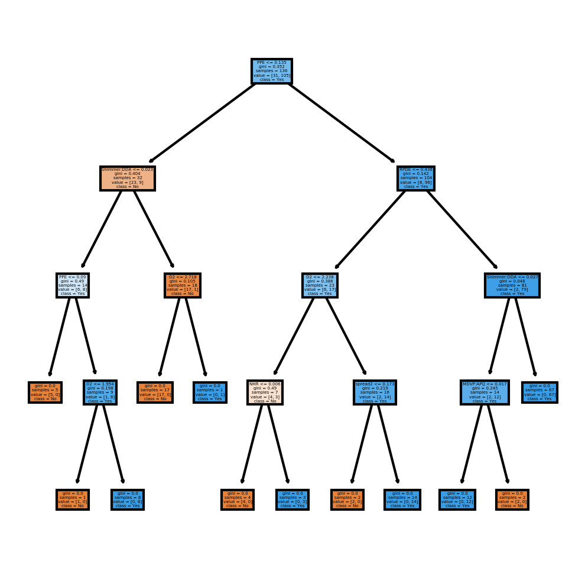

```python
#plotting the decision tree

import matplotlib.pyplot as plt
from sklearn.tree import plot_tree

fn = list(x_train)
cn = ['No', 'Yes']
fig, axes = plt.subplots(nrows = 1,ncols = 1,figsize = (4, 4), dpi=300)
plot_tree(clf_DT, feature_names = fn, class_names=cn, filled = True)

fig.savefig('tree.png')
```

```python
preds_test = clf_DT.predict(x_test)
preds_train = clf_DT.predict(x_train)

# checking accuracies of the Decision tree on the training and test data

acc_DT = accuracy_score(y_test, preds_test) #test accuracy

print(accuracy_score(y_train,preds_train))
print(acc_DT)
```

```
1.0
0.9152542372881356
```

#### Observations

As seen Decision trees are prone to overfitting the train data and hence it is necessary to regularize the decision tree by pruning.

```python
#performing cross validation to check for any improvement
from sklearn.model_selection import cross_val_score
all_accuracies = cross_val_score(estimator=clf_DT, X=x_train, y=y_train, cv=10)
print(all_accuracies.mean())
```

```
0.7939560439560439
```

#### Observations

Cross validation didnt really improve the model as it reduced the accuracy by 10% compared to the base decision tree model

```python
#Perform Grid Search Method to find the optimal max_depth size

from sklearn.model_selection import GridSearchCV
criterion = ['gini', 'entropy']
max_depth = np.arange(1,10)
min_samples_leaf = np.arange(1,10)
param_grid = dict(criterion=criterion, max_depth=max_depth, min_samples_leaf=min_samples_leaf)

GS = GridSearchCV(clf_DT, param_grid=param_grid, n_jobs=1, cv=3)
GS.fit(X,Y)
```

```
GridSearchCV(cv=3, estimator=DecisionTreeClassifier(random_state=22), n_jobs=1,
             param_grid={'criterion': ['gini', 'entropy'],
                         'max_depth': array([1, 2, 3, 4, 5, 6, 7, 8, 9]),
                         'min_samples_leaf': array([1, 2, 3, 4, 5, 6, 7, 8, 9])})
```

```python
# getting the best parameters to tune the decision tree

GS.best_params_
```

```
{'criterion': 'gini', 'max_depth': 1, 'min_samples_leaf': 1}
```

#### from the above the it is observed to set the maximum tree depth as 1 and min samples leaf as 1 for an optimum result

```python
clf_pruned = DecisionTreeClassifier(criterion = "gini", random_state = 22, max_depth=1, min_samples_leaf=1)
clf_pruned.fit(x_train, y_train)

preds_pruned = clf_pruned.predict(x_test)
preds_pruned_train = clf_pruned.predict(x_train)

print(accuracy_score(y_train,preds_pruned_train))
print(accuracy_score(y_test,preds_pruned))
```

```
0.875
0.8305084745762712
```

#### Observations

As observed for the DecisionTree algorithm

1. Base model gave an accuracy of 91% on the test data
2. Cross validation reduced the accuracy by 10% to almost 80%
3. Pruning the tree led to an accuracy of 83% at the same time reduced the overfitting

We shall run further models and check for if they perform well

### Training a Metaclassifier

```python
from mlxtend.classifier import StackingCVClassifier
from sklearn import datasets
from sklearn.svm import SVC
from sklearn.ensemble import RandomForestClassifier
```

```python
clf1 = KNeighborsClassifier()
clf2 = RandomForestClassifier(random_state=22)
clf3 = SVC(probability=True, random_state=22)
clf4 = GaussianNB()
lr = LogisticRegression()

sclf = StackingCVClassifier(classifiers=[clf1, clf2, clf3, clf4],
                    meta_classifier=lr,random_state=22 )

sclf.fit(x_train, y_train)
pred_SCLF = sclf.predict(x_test)
acc_STCK = accuracy_score(y_test, pred_SCLF)
```

```python
#Store the accuracy results for each model in a dataframe for final comparison

resultsDf = pd.DataFrame({'Method':['Stacking'], 'Accuracy': acc_STCK})
resultsDf = resultsDf[['Method', 'Accuracy']]
resultsDf
```

|  | Method | Accuracy |
| --- | --- | --- |
| 0 | Stacking | 0.864407 |

### Training Ensemble Models

1. Random Forest
2. AdaBoost
3. Bagging
4. Gradient Boost
5. Stacking

#### 1. Random Forest

```python
# RandomForest

rfcl = RandomForestClassifier(random_state=22)
rfcl = rfcl.fit(x_train, y_train)

pred_RF = rfcl.predict(x_test)
acc_RF = accuracy_score(y_test, pred_RF)

# Confusion Matrix
cm_RF=metrics.confusion_matrix(y_test, pred_RF, labels=[1, 0])
print('\nConfusion Matrix:\n', cm_RF)
```

```
Confusion Matrix:
 [[40  2]
 [ 4 13]]
```

```python
#Store the accuracy results for each model in a dataframe for final comparison
tempResultsDf = pd.DataFrame({'Method':['Random Forest'], 'Accuracy': acc_RF})
resultsDf = pd.concat([resultsDf, tempResultsDf])
resultsDf = resultsDf[['Method', 'Accuracy']]
resultsDf
```

|  | Method | Accuracy |
| --- | --- | --- |
| 0 | Stacking | 0.864407 |
| 0 | Random Forest | 0.898305 |

```python
#performing cross validation to check if the model improves

RF_cvs = cross_val_score(RandomForestClassifier(random_state=22), X, Y,cv=10)
acc_RF_cv = RF_cvs.mean()
```

```python
#Store the accuracy results for each model in a dataframe for final comparison
tempResultsDf = pd.DataFrame({'Method':['Random Forest CV'], 'Accuracy': acc_RF_cv})
resultsDf = pd.concat([resultsDf, tempResultsDf])
resultsDf = resultsDf[['Method', 'Accuracy']]
resultsDf
```

|  | Method | Accuracy |
| --- | --- | --- |
| 0 | Stacking | 0.864407 |
| 0 | Random Forest | 0.898305 |
| 0 | Random Forest CV | 0.808684 |

#### 2. AdaBoost

```python
from sklearn.ensemble import AdaBoostClassifier

abcl = AdaBoostClassifier(learning_rate=0.1, random_state=22)
abcl = abcl.fit(x_train, y_train)

pred_AB =abcl.predict(x_test)
acc_AB = accuracy_score(y_test, pred_AB)

# Confusion Matrix
cm_AB=metrics.confusion_matrix(y_test, pred_AB, labels=[1, 0])
print('\nConfusion Matrix:\n', cm_AB)
```

```
Confusion Matrix:
 [[42  0]
 [ 7 10]]
```

```python
tempResultsDf = pd.DataFrame({'Method':['Adaboost'], 'Accuracy': [acc_AB]})
resultsDf = pd.concat([resultsDf, tempResultsDf])
resultsDf = resultsDf[['Method', 'Accuracy']]
resultsDf
```

|  | Method | Accuracy |
| --- | --- | --- |
| 0 | Stacking | 0.864407 |
| 0 | Random Forest | 0.898305 |
| 0 | Random Forest CV | 0.808684 |
| 0 | Adaboost | 0.881356 |

#### 3. Bagging

```python
from sklearn.ensemble import BaggingClassifier

bgcl = BaggingClassifier( max_samples= .7, bootstrap=True, oob_score=True, random_state=22)
bgcl = bgcl.fit(x_train, y_train)

pred_BG =bgcl.predict(x_test)
acc_BG = accuracy_score(y_test, pred_BG)

# Confusion Matrix
cm_BG=metrics.confusion_matrix(y_test, pred_BG, labels=[1, 0])
print('\nConfusion Matrix:\n', cm_BG)
```

```
Confusion Matrix:
 [[40  2]
 [ 2 15]]
```

```python
tempResultsDf = pd.DataFrame({'Method':['Bagging'], 'Accuracy': [acc_BG]})
resultsDf = pd.concat([resultsDf, tempResultsDf])
resultsDf = resultsDf[['Method', 'Accuracy']]
resultsDf
```

|  | Method | Accuracy |
| --- | --- | --- |
| 0 | Stacking | 0.864407 |
| 0 | Random Forest | 0.898305 |
| 0 | Random Forest CV | 0.808684 |
| 0 | Adaboost | 0.881356 |
| 0 | Bagging | 0.932203 |

#### 4. GradientBoost

```python
from sklearn.ensemble import GradientBoostingClassifier
gbcl = GradientBoostingClassifier(learning_rate = 0.1, random_state=22)
gbcl = gbcl.fit(x_train, y_train)

pred_GB =gbcl.predict(x_test)
acc_GB = accuracy_score(y_test, pred_GB)

# Confusion Matrix
cm_GB=metrics.confusion_matrix(y_test, pred_GB, labels=[1, 0])
print('\nConfusion Matrix:\n', cm_GB)
```

```
Confusion Matrix:
 [[39  3]
 [ 4 13]]
```

```python
tempResultsDf = pd.DataFrame({'Method':['Gradient Boost'], 'Accuracy': [acc_GB]})
resultsDf = pd.concat([resultsDf, tempResultsDf])
resultsDf = resultsDf[['Method', 'Accuracy']]
resultsDf
```

|  | Method | Accuracy |
| --- | --- | --- |
| 0 | Stacking | 0.864407 |
| 0 | Random Forest | 0.898305 |
| 0 | Random Forest CV | 0.808684 |
| 0 | Adaboost | 0.881356 |
| 0 | Bagging | 0.932203 |
| 0 | Gradient Boost | 0.881356 |

### Final Observations

#### Models and Accuracy

1. Logistic Regression: 0.849
2. Naive Bayes: 0.679
3. KNN: 0.847
4. SVM: 0.864
5. Decision Trees after pruning: 0.830
6. Random Forest: 0.898
7. Random Forest with Crossvalidation: 0.808
8. AdaBoost: 0.881
9. Bagging: 0.932
10. Gradient Boost: 0.881
11. Stacking: 0.864

From the above data it can be seen Bagging performs the best at 93.2% accuracy followed by Random Forest with AdaBoost and GradientBoost all at a close 88% followed by Stacking and SVM at close 87% followed by KNN and Logistic Regression at around 85%. Furhter down the line ar Decision tree and Naive Bayes.

It is noteworthy that Logistic regression being the least expensive model gives an 85% accuracy.

Although Bagging performs the best, any model with close to 90% accuracy can be considered as that is a good enough accuracy to make decisions.